# Biostatistics Methods 1 Final Project

Manqi Cai, Yixi Xu, Peng-Lin Lin, Kaitlin Maciejewski

12/9/2017

The Data Analytics group from Good Health Corporation are interested in improving the overall hospital management and minimizing the cost/resources associated with patients’ care. One of the most important outcomes that has a direct effect on these aspects is patient’s length of stay (LoS) in the hospital. Thus, they would like to know which variables are associated with LoS, and ultimately build a predictive model to be used for future visits. The group has contacted you to study this problem and make a recommendation.

```r
ghproject <- read_excel("GHProject_Dataset.xlsx") %>%
  clean_names()

#summary of continuous variable
ghproject %>%
  select(loshours,losdays2, ageyear, bmi:bpdiastolic) %>%
  summary() %>%
  knitr::kable()
```

|  | loshours | losdays2 | ageyear | bmi | bpsystolic | o2sat | temperature | heartrate | respirationrate | bpdiastolic |
| --- | --- | --- | --- | --- | --- | --- | --- | --- | --- | --- |
|  | Min. : 1.0 | Min. : 0.04167 | Min. : 18.00 | Min. : 3.10 | Min. : 88.78 | Min. : 80.00 | Min. :11.85 | Min. : 37.58 | Min. :12.00 | Min. : 29.56 |
|  | 1st Qu.: 51.0 | 1st Qu.: 2.12500 | 1st Qu.: 54.00 | 1st Qu.: 23.30 | 1st Qu.:117.97 | 1st Qu.: 96.52 | 1st Qu.:36.61 | 1st Qu.: 71.32 | 1st Qu.:17.12 | 1st Qu.: 66.01 |
|  | Median : 92.0 | Median : 3.83333 | Median : 68.00 | Median : 27.10 | Median :129.17 | Median : 97.58 | Median :36.73 | Median : 79.20 | Median :17.76 | Median : 71.85 |
|  | Mean : 131.8 | Mean : 5.48961 | Mean : 65.74 | Mean : 28.33 | Mean :130.52 | Mean : 97.85 | Mean :36.73 | Mean : 80.09 | Mean :18.20 | Mean : 72.53 |
|  | 3rd Qu.: 164.0 | 3rd Qu.: 6.83333 | 3rd Qu.: 81.00 | 3rd Qu.: 31.60 | 3rd Qu.:141.46 | 3rd Qu.: 98.62 | 3rd Qu.:36.87 | 3rd Qu.: 87.61 | 3rd Qu.:18.47 | 3rd Qu.: 77.95 |
|  | Max. :2111.0 | Max. :87.95833 | Max. :105.00 | Max. :122.65 | Max. :193.96 | Max. :236.53 | Max. :52.27 | Max. :242.58 | Max. :67.72 | Max. :154.40 |
|  | NA | NA | NA | NA’s :697 | NA’s :5 | NA’s :3 | NA’s :3 | NA’s :5 | NA’s :3 | NA’s :1 |

```r
attach(ghproject)

sd(loshours)
```

```
## [1] 142.3524
```

```r
sd(losdays2)
```

```
## [1] 5.931351
```

```r
sd(ageyear)
```

```
## [1] 18.66037
```

```r
sd(bmi)
```

```
## [1] NA
```

```r
sd(bpdiastolic)
```

```
## [1] NA
```

```r
sd(o2sat)
```

```
## [1] NA
```

```r
sd(temperature)
```

```
## [1] NA
```

```r
sd(heartrate)
```

```
## [1] NA
```

```r
sd(respirationrate)
```

```
## [1] NA
```

```r
sd(bpsystolic)
```

```
## [1] NA
```

```r
#summary of categorical data
ghproject %>%
  group_by(mews) %>%
  summarize(n())
```

```
## # A tibble: 15 x 2
##     mews `n()`
##    <dbl> <int>
##  1     0    39
##  2     1   618
##  3     2   730
##  4     3   801
##  5     4   711
##  6     5   328
##  7     6   151
##  8     7    87
##  9     8    26
## 10     9    14
## 11    10     5
## 12    11     4
## 13    12     1
## 14    14     1
## 15    NA   166
```

```r
ghproject %>%
  group_by(cindex) %>%
  summarize(n())
```

```
## # A tibble: 5 x 2
##   cindex `n()`
##    <dbl> <int>
## 1      0  1207
## 2      1   636
## 3      2   722
## 4      3   435
## 5      5   682
```

```r
ghproject %>%
  group_by(evisit) %>%
  summarize(n())
```

```
## # A tibble: 5 x 2
##   evisit `n()`
##    <dbl> <int>
## 1      0  1134
## 2      1   752
## 3      2   521
## 4      3   329
## 5      4   946
```

```r
ghproject %>%
  group_by(icu_flag) %>%
  summarize(n())
```

```
## # A tibble: 2 x 2
##   icu_flag `n()`
##      <dbl> <int>
## 1        0  3618
## 2        1    64
```

```r
ghproject %>%
  group_by(gender) %>%
  summarize(n())
```

```
## # A tibble: 2 x 2
##   gender `n()`
##    <chr> <int>
## 1 Female  1981
## 2   Male  1701
```

```r
ghproject %>%
  group_by(race) %>%
  summarize(n())
```

```
## # A tibble: 6 x 2
##                   race `n()`
##                  <chr> <int>
## 1   African Amer/Black   788
## 2                Asian   253
## 3  Native Amer/Alaskan    22
## 4 Natv Hawaii/Pacf Isl     4
## 5    Other/Multiracial   526
## 6                White  2089
```

```r
ghproject %>%
  group_by(religion) %>%
  summarize(n())
```

```
## # A tibble: 11 x 2
##              religion `n()`
##                 <chr> <int>
##  1          Angelican     1
##  2           Catholic  1678
##  3          Christian   909
##  4             Hebrew     1
##  5              Hindu   127
##  6              Islam   112
##  7             Jewish   527
##  8             Mormon     2
##  9     No Affiliation   177
## 10 Non Denominational     1
## 11              Other   147
```

```r
ghproject %>%
  group_by(maritalstatus) %>%
  summarize(n())
```

```
## # A tibble: 7 x 2
##   maritalstatus `n()`
##           <chr> <int>
## 1   Civil Union     1
## 2      Divorced   241
## 3       Married  1637
## 4     Separated    52
## 5        Single   967
## 6       Widowed   704
## 7          <NA>    80
```

```r
ghproject %>%
  group_by(facilityname) %>%
  summarize(n())
```

```
## # A tibble: 8 x 2
##                  facilityname `n()`
##                         <chr> <int>
## 1         Lenox Hill Hospital     5
## 2            LIJ Forest Hills   568
## 3           LIJ Valley Stream   331
## 4 Long Island Jewish Hospital   828
## 5                        NSUH  1011
## 6          Plainview Hospital   328
## 7          Southside Hospital   528
## 8            Syosset Hospital    83
```

```r
ghproject %>%
  group_by(insurancetype) %>%
  summarize(n())
```

```
## # A tibble: 4 x 2
##   insurancetype `n()`
##           <chr> <int>
## 1      Medicaid   170
## 2      Medicare  1457
## 3       Private  2021
## 4          <NA>    34
```

```r
#summary of PatientID and VisitID
ghproject %>%
  distinct(patientid) %>%
  count()
```

```
## # A tibble: 1 x 1
##       n
##   <int>
## 1  3612
```

```r
ghproject %>%
  distinct(visitid) %>%
  count()
```

```
## # A tibble: 1 x 1
##       n
##   <int>
## 1  3682
```

There are 3682 records from 3612 patients

```r
GHProject_Dataset <- read_excel("GHProject_Dataset.xlsx") %>% clean_names() #load data

#remove duplicated patients
ghproject_remove <- GHProject_Dataset[!duplicated(GHProject_Dataset[c('patientid')]),]


#
##recode variables
ghproject_tidy <- ghproject_remove %>%
  mutate(gender = ifelse(gender == "Male", "1","0" )) %>% #recode gender
  mutate(maritalstatus = ifelse(maritalstatus == "Married","1","0"), #recode marital status
         cindex = recode(cindex, #recode cindex
                         "0" = "0",
                         "1" = "0",
                         "2" = "1",
                         "3" = "1",
                         "4" = "2",
                         "5" = "2"),
         insurancetype = recode(insurancetype, #recode insurance type
                                "NA" = "0",
                                "Private" = "1",
                                "Medicare" = "2",
                                "Medicaid" = "3"),
         mews = recode(mews, #recode mews
                       "NA" = "0",
                       "0" = "1",
                       "1" = "1",
                       "2" = "2",
                       "3" = "2",
                       "4" = "3",
                       "5" = "3",
                       "6"= "4",
                       "7"= "4",
                       "8"= "4",
                       "9"= "4",
                       "10"= "4",
                       "11"= "4",
                       "12"= "4",
                       "13"= "4",
                       "14" = "4"),
         religion = ifelse(religion == "No Affiliation", "0", "1"), #recode religion
         losdays2_log = log(losdays2),
         id = 1:nrow(ghproject_remove)) %>%
  separate(admitdtm, into= c("day", "month", "year"), sep = ", ", convert = TRUE) %>% #recode admission date to month
  mutate(month = str_replace(month, "[0-9]", ""))%>%
  mutate(month = str_replace(month, "[0-9]", ""))%>%
  mutate(month = str_replace(month, " ", ""))%>%
  mutate(month = recode(month,
                        "January" = "1",
                        "February" = "2",
                        "March" = "3",
                        "April" = "4",
                        "May" = "5",
                        "June" = "6",
                        "July" = "7",
                        "August" = "8",
                        "September" = "9",
                        "October" = "10",
                        "November" = "11",
                        "December" = "12")) %>%
  select(-c(day, year, patientid, visitid, postalcode, facilityname, facilityzip, race)) %>% #remove unneeded variables
    na.omit()
ghproject_tidy$mews <- as.integer(as.character(ghproject_tidy$mews))

ghproject_tidy$cindex <- as.integer(as.character(ghproject_tidy$cindex))

ghproject_tidy$month <- as.integer(as.character(ghproject_tidy$month))

ghproject_tidy$gender <- as.integer(as.character(ghproject_tidy$gender))

ghproject_tidy$religion <- as.integer(as.character(ghproject_tidy$religion))

ghproject_tidy$maritalstatus <- as.integer(as.character(ghproject_tidy$maritalstatus))

ghproject_tidy$insurancetype <- as.integer(as.character(ghproject_tidy$insurancetype))
```

```r
attach(ghproject_tidy)
```

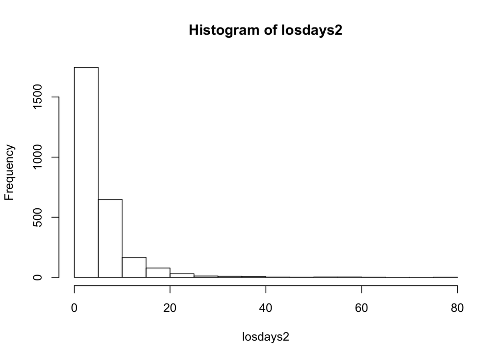

```r
hist(losdays2)
```

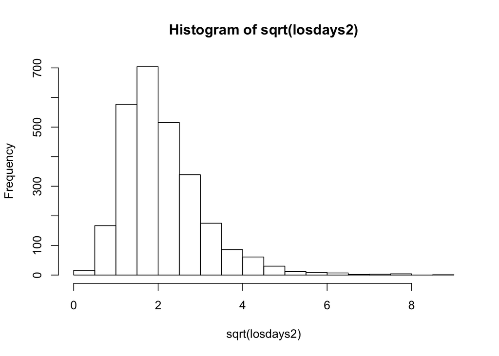

```r
hist(sqrt(losdays2))
```

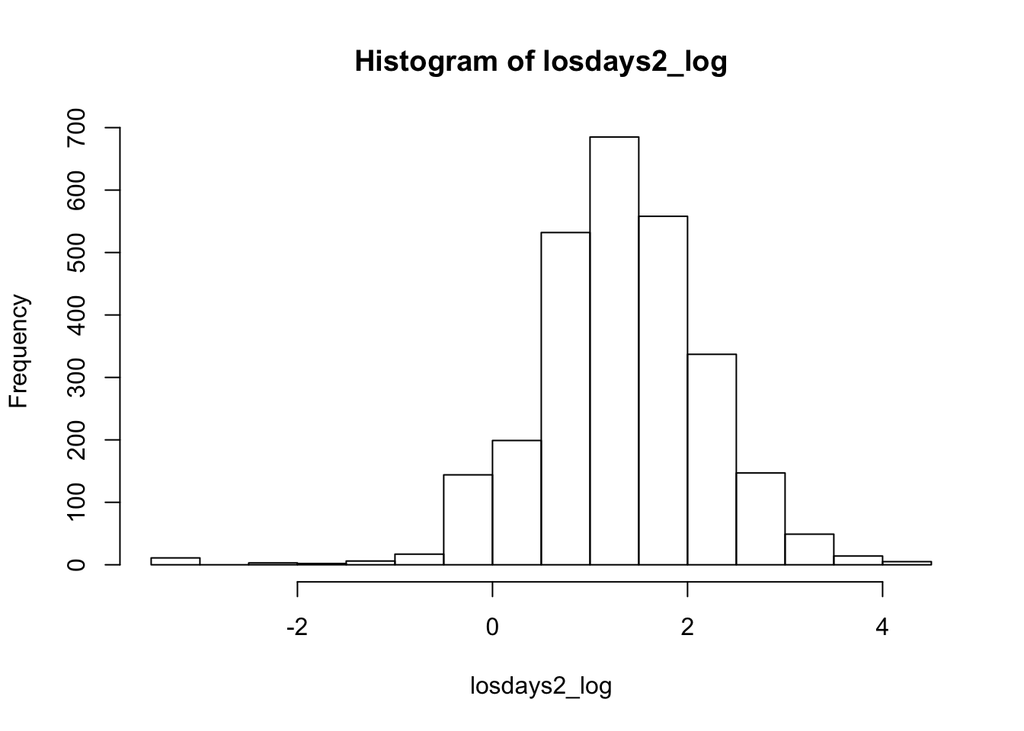

```r
hist(losdays2_log)
```

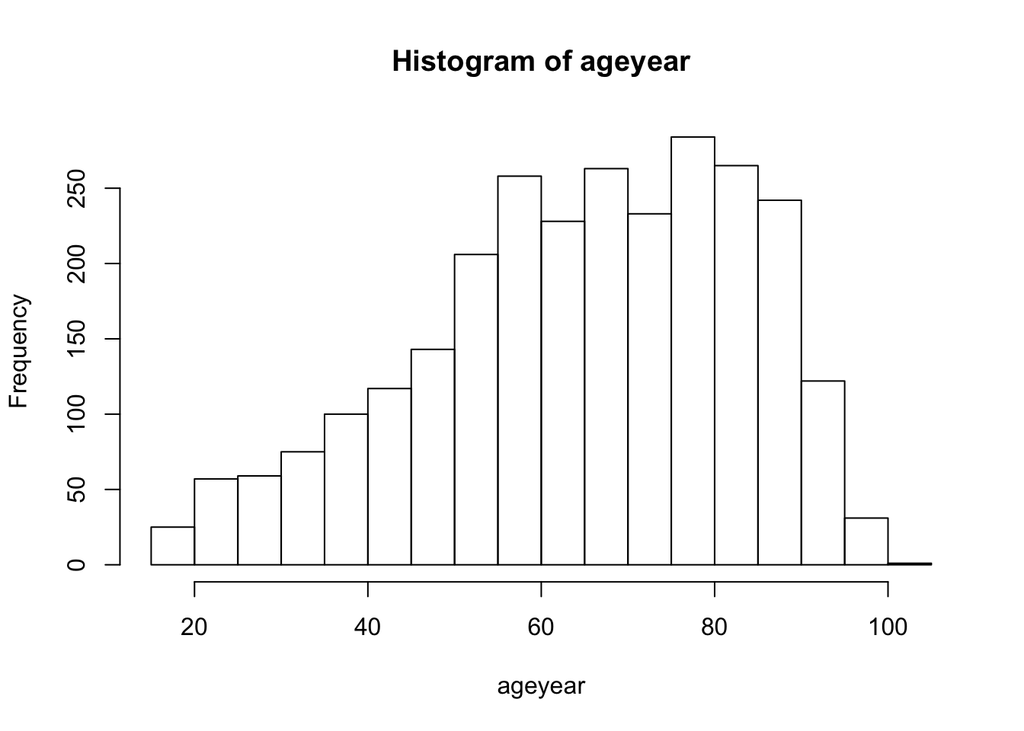

```r
hist(ageyear)
```

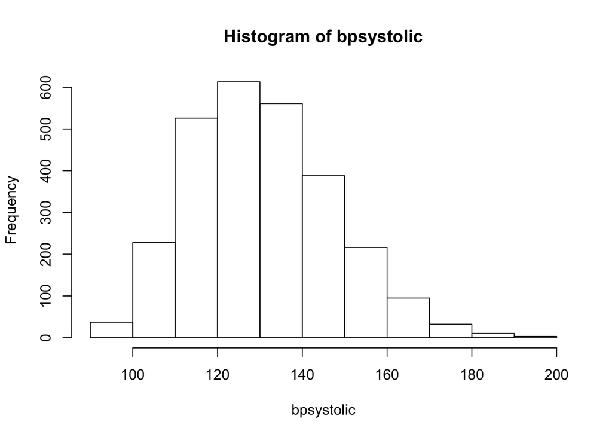

```r
#hist(bmi)
hist(bpsystolic)
```

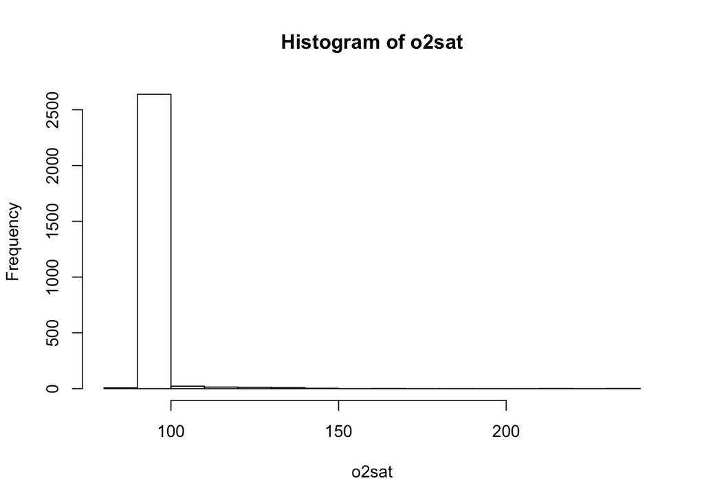

```r
hist(o2sat)
```

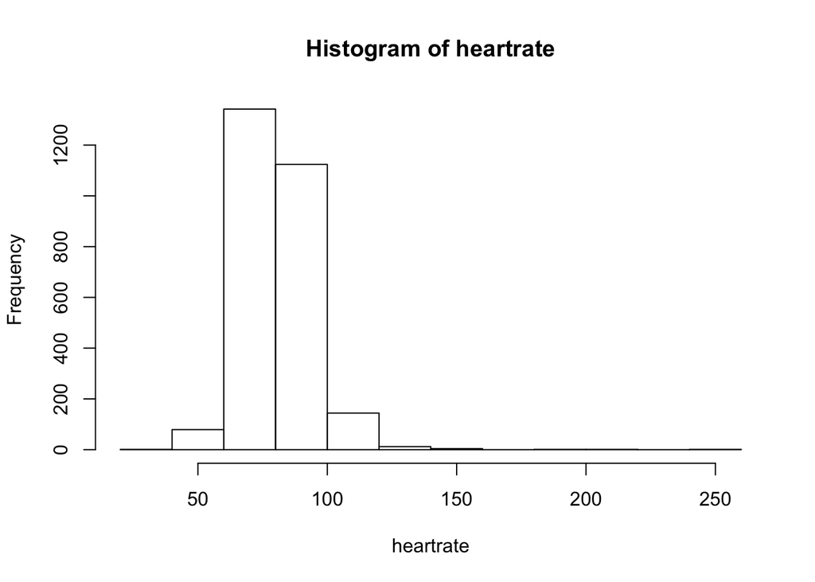

```r
#hist(temperature)
hist(heartrate)
```

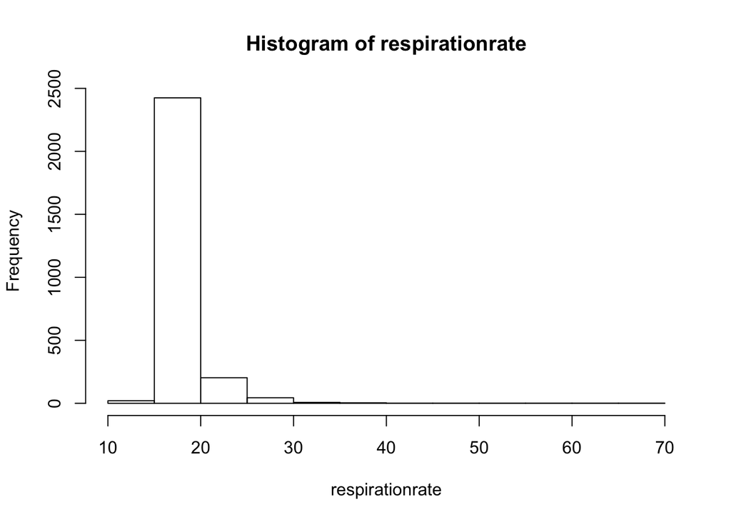

```r
hist(respirationrate)
```

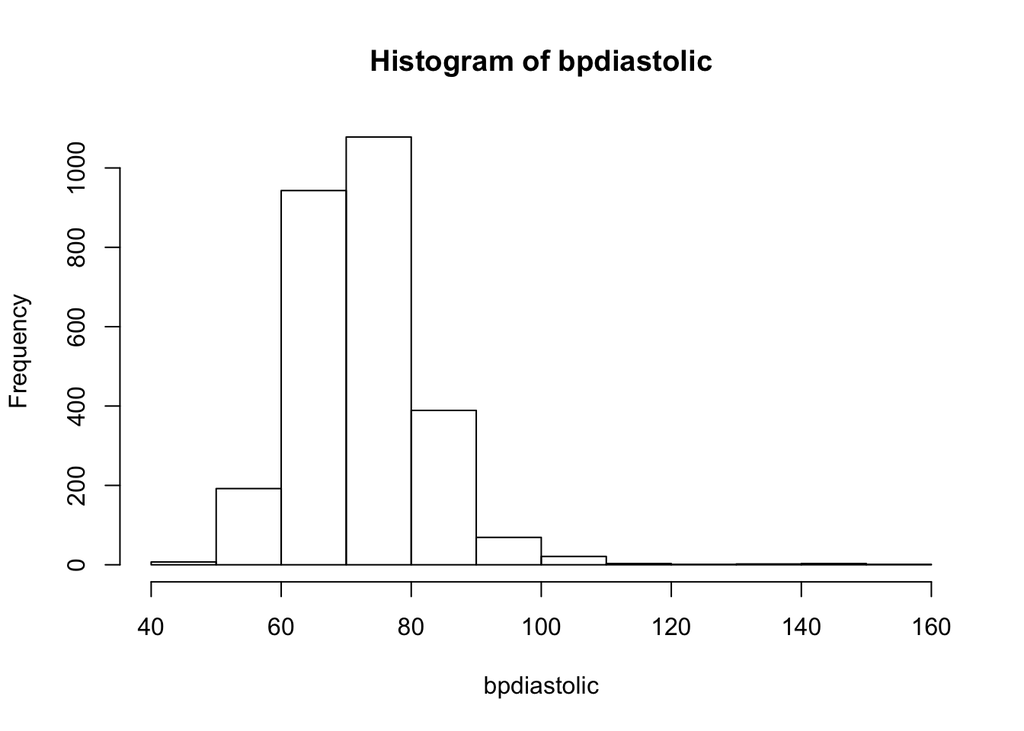

```r
hist(bpdiastolic)
```

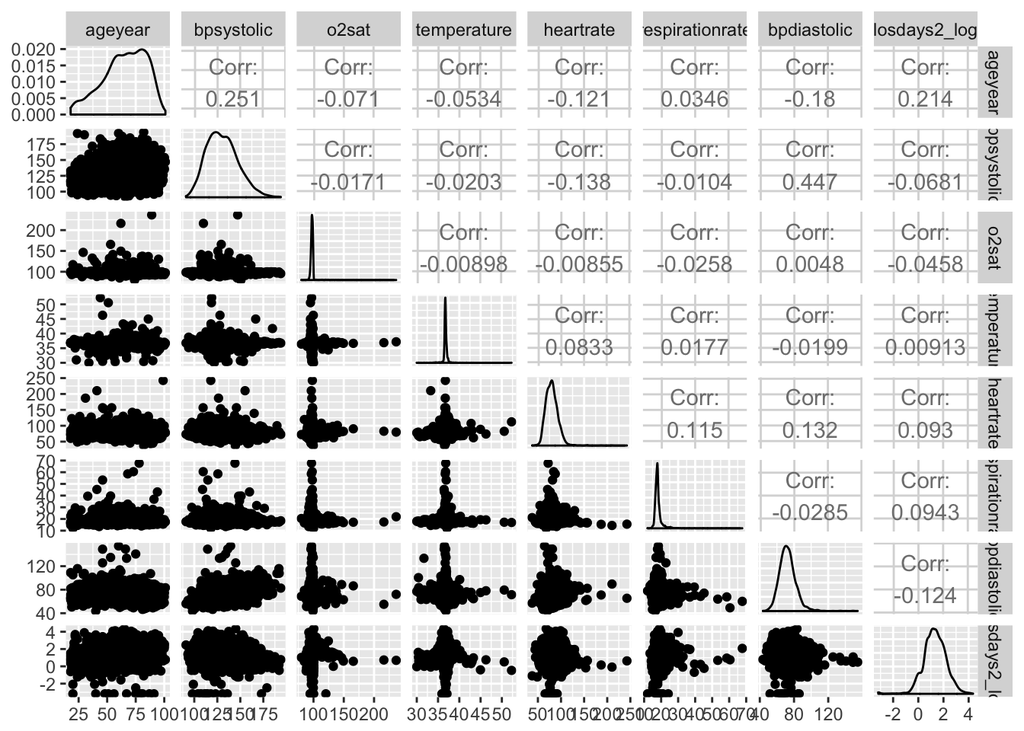

```r
# correlation matrix for numeric variables, saturated
ggpairs(ghproject_tidy, columns = c("ageyear", "bpsystolic","o2sat","temperature", "heartrate","respirationrate", "bpdiastolic","losdays2_log"))
```

```r
# no significant linear trend ??
```

```r
write_csv(ghproject_tidy, "ghproject_saturated.csv")
```

# SAS output:

## Forward

### significant variables:

ageyear, evisit, bpsystolic, cindex, heartrate, is30dayreadmit, respirationrate

AdjR2: 0.1169

AIC: 1743.8

## Backward

AdjR2: 0.1169

AIC: 1743.8

## Stepwise

### significant variables:

ageyear, evisit, bpsystolic, cindex, heartrate, is30dayreadmit, respirationrate

AdjR2: 0.1169

AIC: 1743.8

All models agree

```r
reg_30 <- lm(losdays2_log ~ is30dayreadmit, ghproject_tidy)
summary(reg_30)
```

```
##
## Call:
## lm(formula = losdays2_log ~ is30dayreadmit, data = ghproject_tidy)
##
## Residuals:
##     Min      1Q  Median      3Q     Max
## -4.7929 -0.5528  0.0192  0.5526  3.0842
##
## Coefficients:
##                Estimate Std. Error t value Pr(>|t|)
## (Intercept)     1.26671    0.01824  69.459  < 2e-16 ***
## is30dayreadmit  0.34827    0.04869   7.153 1.09e-12 ***
## ---
## Signif. codes:  0 '***' 0.001 '**' 0.01 '*' 0.05 '.' 0.1 ' ' 1
##
## Residual standard error: 0.8801 on 2707 degrees of freedom
## Multiple R-squared:  0.01855,    Adjusted R-squared:  0.01819
## F-statistic: 51.16 on 1 and 2707 DF,  p-value: 1.091e-12
```

```r
reg_cindex <- lm(losdays2_log ~ cindex, ghproject_tidy)
summary(reg_cindex)
```

```
##
## Call:
## lm(formula = losdays2_log ~ cindex, data = ghproject_tidy)
##
## Residuals:
##     Min      1Q  Median      3Q     Max
## -4.5679 -0.5176 -0.0105  0.5665  2.7903
##
## Coefficients:
##             Estimate Std. Error t value Pr(>|t|)
## (Intercept)  1.16825    0.02227   52.46   <2e-16 ***
## cindex       0.22170    0.02207   10.04   <2e-16 ***
## ---
## Signif. codes:  0 '***' 0.001 '**' 0.01 '*' 0.05 '.' 0.1 ' ' 1
##
## Residual standard error: 0.8723 on 2707 degrees of freedom
## Multiple R-squared:  0.03594,    Adjusted R-squared:  0.03558
## F-statistic: 100.9 on 1 and 2707 DF,  p-value: < 2.2e-16
```

```r
reg_evisit <- lm(losdays2_log ~ evisit, ghproject_tidy)
summary(reg_evisit)
```

```
##
## Call:
## lm(formula = losdays2_log ~ evisit, data = ghproject_tidy)
##
## Residuals:
##     Min      1Q  Median      3Q     Max
## -4.5204 -0.5368  0.0097  0.5560  3.2078
##
## Coefficients:
##             Estimate Std. Error t value Pr(>|t|)
## (Intercept)  1.14308    0.02495   45.82   <2e-16 ***
## evisit       0.09969    0.01066    9.35   <2e-16 ***
## ---
## Signif. codes:  0 '***' 0.001 '**' 0.01 '*' 0.05 '.' 0.1 ' ' 1
##
## Residual standard error: 0.8744 on 2707 degrees of freedom
## Multiple R-squared:  0.03129,    Adjusted R-squared:  0.03093
## F-statistic: 87.43 on 1 and 2707 DF,  p-value: < 2.2e-16
```

```r
reg_age <- lm(losdays2_log ~ ageyear, ghproject_tidy)
summary(reg_age)
```

```
##
## Call:
## lm(formula = losdays2_log ~ ageyear, data = ghproject_tidy)
##
## Residuals:
##     Min      1Q  Median      3Q     Max
## -4.7580 -0.5154 -0.0094  0.5353  3.0374
##
## Coefficients:
##             Estimate Std. Error t value Pr(>|t|)
## (Intercept) 0.647232   0.060881   10.63   <2e-16 ***
## ageyear     0.010250   0.000898   11.41   <2e-16 ***
## ---
## Signif. codes:  0 '***' 0.001 '**' 0.01 '*' 0.05 '.' 0.1 ' ' 1
##
## Residual standard error: 0.8677 on 2707 degrees of freedom
## Multiple R-squared:  0.04592,    Adjusted R-squared:  0.04556
## F-statistic: 130.3 on 1 and 2707 DF,  p-value: < 2.2e-16
```

```r
reg_gender <- lm(losdays2_log ~ gender, ghproject_tidy)
summary(reg_gender)
```

```
##
## Call:
## lm(formula = losdays2_log ~ gender, data = ghproject_tidy)
##
## Residuals:
##     Min      1Q  Median      3Q     Max
## -4.4967 -0.5649  0.0211  0.5917  3.0391
##
## Coefficients:
##              Estimate Std. Error t value Pr(>|t|)
## (Intercept)  1.318789   0.023218  56.800   <2e-16 ***
## gender      -0.007022   0.034249  -0.205    0.838
## ---
## Signif. codes:  0 '***' 0.001 '**' 0.01 '*' 0.05 '.' 0.1 ' ' 1
##
## Residual standard error: 0.8884 on 2707 degrees of freedom
## Multiple R-squared:  1.553e-05,  Adjusted R-squared:  -0.0003539
## F-statistic: 0.04204 on 1 and 2707 DF,  p-value: 0.8376
```

```r
reg_marital <- lm(losdays2_log ~ maritalstatus, ghproject_tidy)
summary(reg_marital)
```

```
##
## Call:
## lm(formula = losdays2_log ~ maritalstatus, data = ghproject_tidy)
##
## Residuals:
##     Min      1Q  Median      3Q     Max
## -4.5397 -0.5678  0.0142  0.5723  3.0899
##
## Coefficients:
##               Estimate Std. Error t value Pr(>|t|)
## (Intercept)    1.36172    0.02316  58.803  < 2e-16 ***
## maritalstatus -0.10067    0.03420  -2.944  0.00327 **
## ---
## Signif. codes:  0 '***' 0.001 '**' 0.01 '*' 0.05 '.' 0.1 ' ' 1
##
## Residual standard error: 0.887 on 2707 degrees of freedom
## Multiple R-squared:  0.003191,   Adjusted R-squared:  0.002822
## F-statistic: 8.665 on 1 and 2707 DF,  p-value: 0.003272
```

```r
reg_insurance <- lm(losdays2_log ~ insurancetype, ghproject_tidy)
summary(reg_insurance)
```

```
##
## Call:
## lm(formula = losdays2_log ~ insurancetype, data = ghproject_tidy)
##
## Residuals:
##     Min      1Q  Median      3Q     Max
## -4.8241 -0.5351 -0.0283  0.5544  2.9242
##
## Coefficients:
##               Estimate Std. Error t value Pr(>|t|)
## (Intercept)    0.98786    0.04596  21.495  < 2e-16 ***
## insurancetype  0.21941    0.02862   7.667 2.44e-14 ***
## ---
## Signif. codes:  0 '***' 0.001 '**' 0.01 '*' 0.05 '.' 0.1 ' ' 1
##
## Residual standard error: 0.8789 on 2707 degrees of freedom
## Multiple R-squared:  0.02125,    Adjusted R-squared:  0.02089
## F-statistic: 58.78 on 1 and 2707 DF,  p-value: 2.44e-14
```

```r
reg_bps <- lm(losdays2_log ~ bpsystolic, ghproject_tidy)
summary(reg_bps)
```

```
##
## Call:
## lm(formula = losdays2_log ~ bpsystolic, data = ghproject_tidy)
##
## Residuals:
##     Min      1Q  Median      3Q     Max
## -4.6112 -0.5616  0.0153  0.5590  3.0877
##
## Coefficients:
##              Estimate Std. Error t value Pr(>|t|)
## (Intercept)  1.787440   0.133884  13.351  < 2e-16 ***
## bpsystolic  -0.003614   0.001017  -3.553 0.000387 ***
## ---
## Signif. codes:  0 '***' 0.001 '**' 0.01 '*' 0.05 '.' 0.1 ' ' 1
##
## Residual standard error: 0.8863 on 2707 degrees of freedom
## Multiple R-squared:  0.004643,   Adjusted R-squared:  0.004275
## F-statistic: 12.63 on 1 and 2707 DF,  p-value: 0.0003868
```

```r
reg_o2 <- lm(losdays2_log ~ o2sat, ghproject_tidy)
summary(reg_o2)
```

```
##
## Call:
## lm(formula = losdays2_log ~ o2sat, data = ghproject_tidy)
##
## Residuals:
##     Min      1Q  Median      3Q     Max
## -4.5200 -0.5667  0.0161  0.5881  3.0554
##
## Coefficients:
##              Estimate Std. Error t value Pr(>|t|)
## (Intercept)  2.067048   0.315163   6.559 6.48e-11 ***
## o2sat       -0.007676   0.003215  -2.388    0.017 *
## ---
## Signif. codes:  0 '***' 0.001 '**' 0.01 '*' 0.05 '.' 0.1 ' ' 1
##
## Residual standard error: 0.8874 on 2707 degrees of freedom
## Multiple R-squared:  0.002102,   Adjusted R-squared:  0.001733
## F-statistic: 5.702 on 1 and 2707 DF,  p-value: 0.01701
```

```r
reg_heart <- lm(losdays2_log ~ heartrate, ghproject_tidy)
summary(reg_heart)
```

```
##
## Call:
## lm(formula = losdays2_log ~ heartrate, data = ghproject_tidy)
##
## Residuals:
##     Min      1Q  Median      3Q     Max
## -4.5648 -0.5437  0.0184  0.5776  3.1111
##
## Coefficients:
##             Estimate Std. Error t value Pr(>|t|)
## (Intercept) 0.818596   0.103610   7.901 4.00e-15 ***
## heartrate   0.006199   0.001275   4.862 1.23e-06 ***
## ---
## Signif. codes:  0 '***' 0.001 '**' 0.01 '*' 0.05 '.' 0.1 ' ' 1
##
## Residual standard error: 0.8845 on 2707 degrees of freedom
## Multiple R-squared:  0.008658,   Adjusted R-squared:  0.008292
## F-statistic: 23.64 on 1 and 2707 DF,  p-value: 1.226e-06
```

```r
reg_resp <- lm(losdays2_log ~ respirationrate, ghproject_tidy)
summary(reg_resp)
```

```
##
## Call:
## lm(formula = losdays2_log ~ respirationrate, data = ghproject_tidy)
##
## Residuals:
##     Min      1Q  Median      3Q     Max
## -4.6743 -0.5615  0.0213  0.5716  3.0100
##
## Coefficients:
##                 Estimate Std. Error t value Pr(>|t|)
## (Intercept)     0.762037   0.113595   6.708 2.39e-11 ***
## respirationrate 0.030395   0.006167   4.928 8.80e-07 ***
## ---
## Signif. codes:  0 '***' 0.001 '**' 0.01 '*' 0.05 '.' 0.1 ' ' 1
##
## Residual standard error: 0.8844 on 2707 degrees of freedom
## Multiple R-squared:  0.008892,   Adjusted R-squared:  0.008526
## F-statistic: 24.29 on 1 and 2707 DF,  p-value: 8.797e-07
```

```r
reg_bpd <- lm(losdays2_log ~ bpdiastolic, ghproject_tidy)
summary(reg_bpd)
```

```
##
## Call:
## lm(formula = losdays2_log ~ bpdiastolic, data = ghproject_tidy)
##
## Residuals:
##     Min      1Q  Median      3Q     Max
## -4.7226 -0.5414  0.0174  0.5620  3.1573
##
## Coefficients:
##              Estimate Std. Error t value Pr(>|t|)
## (Intercept)  2.125599   0.126103  16.856  < 2e-16 ***
## bpdiastolic -0.011171   0.001723  -6.482 1.07e-10 ***
## ---
## Signif. codes:  0 '***' 0.001 '**' 0.01 '*' 0.05 '.' 0.1 ' ' 1
##
## Residual standard error: 0.8816 on 2707 degrees of freedom
## Multiple R-squared:  0.01529,    Adjusted R-squared:  0.01492
## F-statistic: 42.02 on 1 and 2707 DF,  p-value: 1.069e-10
```

```r
reg <- lm(losdays2_log ~ is30dayreadmit + ageyear +  cindex  + insurancetype + bpsystolic + o2sat + heartrate +  respirationrate, ghproject_tidy)

summary(reg)
```

```
##
## Call:
## lm(formula = losdays2_log ~ is30dayreadmit + ageyear + cindex +
##     insurancetype + bpsystolic + o2sat + heartrate + respirationrate,
##     data = ghproject_tidy)
##
## Residuals:
##     Min      1Q  Median      3Q     Max
## -5.0899 -0.4820  0.0048  0.5188  2.9834
##
## Coefficients:
##                   Estimate Std. Error t value Pr(>|t|)
## (Intercept)      0.7674030  0.3663017   2.095 0.036264 *
## is30dayreadmit   0.2597481  0.0468562   5.544 3.25e-08 ***
## ageyear          0.0092775  0.0009619   9.645  < 2e-16 ***
## cindex           0.1364620  0.0221881   6.150 8.88e-10 ***
## insurancetype    0.1130282  0.0284840   3.968 7.43e-05 ***
## bpsystolic      -0.0057149  0.0010042  -5.691 1.40e-08 ***
## o2sat           -0.0044032  0.0030484  -1.444 0.148733
## heartrate        0.0058341  0.0012381   4.712 2.58e-06 ***
## respirationrate  0.0195876  0.0059103   3.314 0.000931 ***
## ---
## Signif. codes:  0 '***' 0.001 '**' 0.01 '*' 0.05 '.' 0.1 ' ' 1
##
## Residual standard error: 0.8388 on 2700 degrees of freedom
## Multiple R-squared:  0.1109, Adjusted R-squared:  0.1083
## F-statistic: 42.09 on 8 and 2700 DF,  p-value: < 2.2e-16
```

```r
confint(reg)
```

```
##                        2.5 %       97.5 %
## (Intercept)      0.049142821  1.485663164
## is30dayreadmit   0.167870341  0.351625827
## ageyear          0.007391456  0.011163552
## cindex           0.092954613  0.179969435
## insurancetype    0.057175656  0.168880799
## bpsystolic      -0.007683974 -0.003745901
## o2sat           -0.010380604  0.001574214
## heartrate        0.003406370  0.008261864
## respirationrate  0.007998328  0.031176774
```

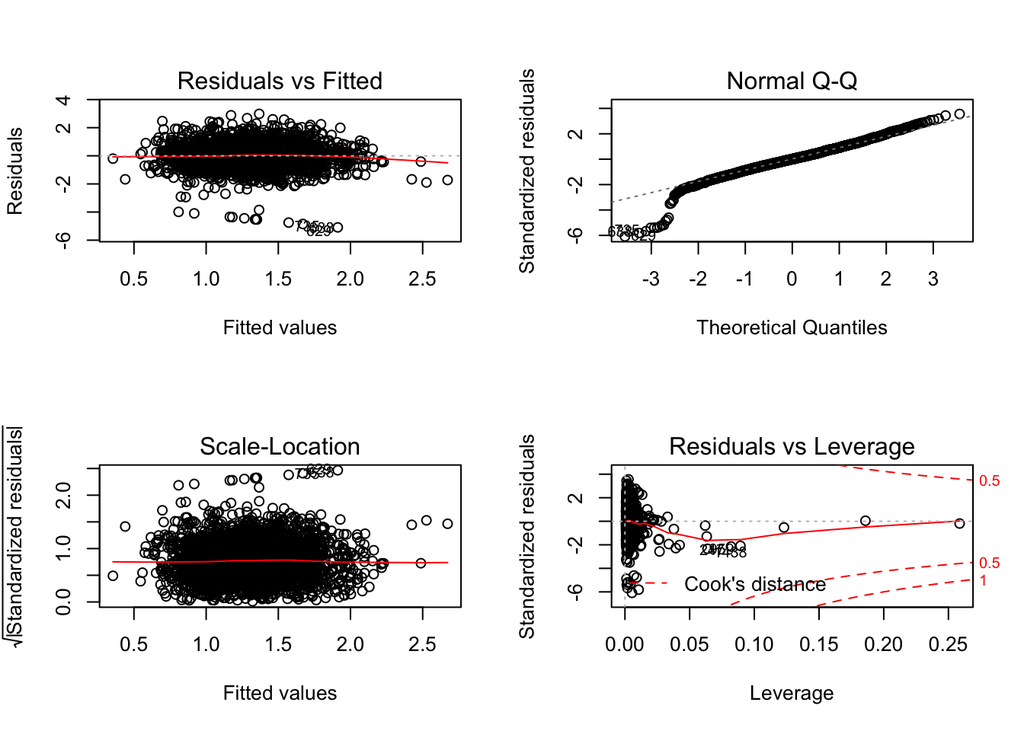

```r
par(mfrow=c(2,2))
plot(reg)
```

```r
# load the library
library(caret)
# define training control
train_control <- trainControl(method="cv", number=10)
# fix the parameters of the algorithm
grid <- expand.grid(.fL=c(0), .usekernel=c(FALSE))
# train the model
model <- train(losdays2_log ~ + is30dayreadmit + ageyear + cindex + evisit + gender + maritalstatus + insurancetype + bpsystolic + o2sat + heartrate +  respirationrate + bpdiastolic, data=ghproject_tidy, trControl=train_control, method='lm')
# summarize results
print(model)
```

```
## Linear Regression
##
## 2709 samples
##   12 predictor
##
## No pre-processing
## Resampling: Cross-Validated (10 fold)
## Summary of sample sizes: 2439, 2438, 2437, 2438, 2438, 2438, ...
## Resampling results:
##
##   RMSE       Rsquared   MAE
##   0.8316603  0.1231733  0.6253312
##
## Tuning parameter 'intercept' was held constant at a value of TRUE
```